# Redes relacionales con R

Las redes relacionales son una manera de visualizar información que resulta muy útil para datos cualitativos y cuantitativos.

Como su nombre lo indica, este tipo de redes son utilizadas para mostrar relaciones entre datos, generalente nominales (nombres, categorías, etiquetas). Por ejemplo, la afinidad entre los integrantes de un equipo de trabajo, los principales clientes de diferentes centros de distribución, dependenciencias entre procesos y muchas otras cosas más.

Para esta entrada, usaremos como ejemplo datos de la serie de juegos *Pokemon*.

# Una introducción muy general a Pokemon

Cada Pokemon tiene un **tipo** que determina sus estadísticas de ataque y defensa así como las habilidades que puede aprender.

Además, los tipos de Pokemon determinan fortalezas y debilidad en un complejo sistema, similar al juego “Piedra, papel y tijera”.

Por ejemplo, un Pokemon de tipo **agua** es fuerte contra uno de tipo **fuego** estos, a su vez, son fuertes contra los de tipo **planta**, y este último tipo de Pokemon es fuerte contra los de tipo **agua**.

# Paquetes necesarios

Utilizaremos los siguientes paquetes para este análisis.

- *tidyverse* - Una familia de paquetes para importar, procesar, visualizar y exportar datos de forma ordenada.
- *igraph* - Este paquete nos ayudará a transformar data frames en datos apropiados para generar redes relacionales.
- *ggraph* - Un agregado al paquete *ggplot2* de *tidyverse* que contiene las funciones necesarias para visualizar redes relacionales.

Como siempre, si no cuentas con alguno de estos paquetes puedes usar la función `install.packages()` para instalarlos.

Cargamos los paquetes a nuestro espacio de trabajo con `library()`.

```r
library(tidyverse)
library(igraph)
library(ggraph)
```

# Descarga de datos

Usaremos la copia de un conjunto de datos publicado originalmente en Kaggle. Este conjunto contiene datos de 800 especies de pokemon distintas con varias características para cada uno de ellos.

The Complete Pokemon Dataset:

- https://www.kaggle.com/rounakbanik/pokemon

Descargaremos este conjunto de datos desde Github y obtenemos como resultado el archivo “pokemon.csv”.

```r
download.file(
  url = "https://raw.githubusercontent.com/jboscomendoza/rpubs/master/pokemon_red/pokemon.csv",
  destfile = "pokemon.csv")
```

# Lectura de datos

Como tenemos un archivo con extensión .csv, usamos la función `read_csv`.

```r
pokemon <- read_csv("pokemon.csv")
```

Veamos nuestro resultado.

```r
pokemon
```

```
## # A tibble: 801 x 41
##    abilities against_bug against_dark against_dragon against_electric
##    <chr>           <dbl>        <dbl>          <dbl>            <dbl>
##  1 ['Overgr~        1               1              1              0.5
##  2 ['Overgr~        1               1              1              0.5
##  3 ['Overgr~        1               1              1              0.5
##  4 ['Blaze'~        0.5             1              1              1
##  5 ['Blaze'~        0.5             1              1              1
##  6 ['Blaze'~        0.25            1              1              2
##  7 ['Torren~        1               1              1              2
##  8 ['Torren~        1               1              1              2
##  9 ['Torren~        1               1              1              2
## 10 ['Shield~        1               1              1              1
## # ... with 791 more rows, and 36 more variables: against_fairy <dbl>,
## #   against_fight <dbl>, against_fire <dbl>, against_flying <dbl>,
## #   against_ghost <dbl>, against_grass <dbl>, against_ground <dbl>,
## #   against_ice <dbl>, against_normal <dbl>, against_poison <dbl>,
## #   against_psychic <dbl>, against_rock <dbl>, against_steel <dbl>,
## #   against_water <dbl>, attack <int>, base_egg_steps <int>,
## #   base_happiness <int>, base_total <int>, capture_rate <chr>,
## #   classfication <chr>, defense <int>, experience_growth <int>,
## #   height_m <dbl>, hp <int>, japanese_name <chr>, name <chr>,
## #   percentage_male <dbl>, pokedex_number <int>, sp_attack <int>,
## #   sp_defense <int>, speed <int>, type1 <chr>, type2 <chr>,
## #   weight_kg <dbl>, generation <int>, is_legendary <int>
```

# Procesamiento de datos

Ahora sí, empezamos con lo interesante, procesar los datos.

```r
poke_fuerza <-
  pokemon %>%
  filter(is.na(type2)) %>%
  select(tipo = type1, starts_with("against")) %>%
  gather("enemigo", "modificador", against_bug:against_water) %>%
  mutate(enemigo = gsub("against_", "", enemigo),
         enemigo = gsub("fight", "fighting", enemigo)) %>%
  distinct() %>%
  filter(modificador != 1) %>%
  mutate(Relacion = ifelse(modificador < 1, "Debil", "Fuerte")) %>%
  select(enemigo, tipo, modificador, Relacion) %>%
  graph_from_data_frame()
```

Veamos la clase del objeto que hemos creado con `graph_from_data_frame()`.

```r
class(poke_fuerza)
```

```
## [1] "igraph"
```

Ahora que tenemos un objeto de clase *igraph* que podemos crear visualizaciones de redes relacionales. Para ello, tenemos dos métodos:

- La función *plot()*
- El paquete *ggraph*

# Generación de redes relacionales usando *plot()*

Para crear la visualización de una red relacional con *plot()*, debemos cargar primero el paquete *igraph*, de este modos se anexan nuevos métodos a esta función.

Hecho esto, basta con usar nuestro objeto *igraph* como argumento para `plot()`.

[figure not shown]

```r
plot(poke_fuerza)
```

Obtenemos una visualización bastante aceptable considerando el mínimo esfuerzo invertido en crearla. Tenemos una buena representación de las uniones y nodos de nuestra red, así como de la direccionalidad de las uniones.

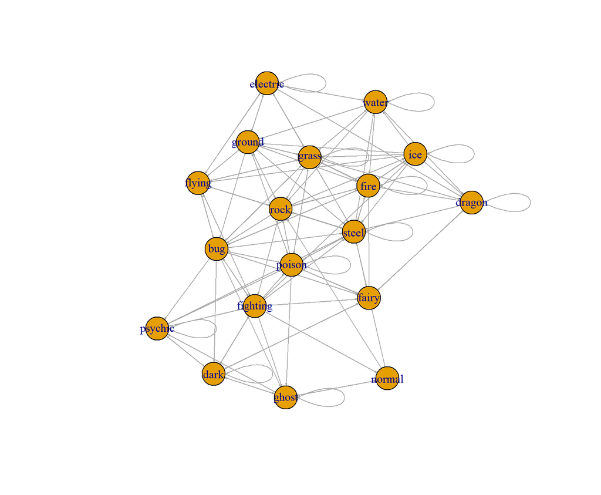

```r
poke_fuerza%>%
  plot(layout = layout_with_graphopt, edge.arrow.size = 0.15)
```

Es posible lograr un control más fino de la visualización obtenida. Por ejemplo, podemos obtener una red circular con esferas en los nodos.

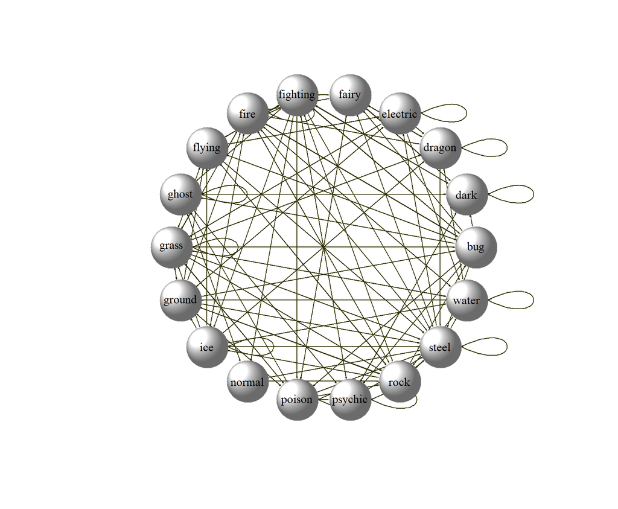

```r
plot(poke_fuerza, layout = layout.circle(poke_fuerza),
     edge.arrow.size = .1,
     vertex.size = 28, vertex.color = "#ffffff",
     edge.color = "#333300", vertex.label.color = "black",
     vertex.shape = "sphere")
```

# Generación de redes relacionales con *ggraph*

Todas las redes relacionales generadas con *ggraph* necesitan de especificaciones las uniones (edges) y los nodos (nodes). Es indispensable contar con al menos una de estas especificaciones para generar una red, pero no es absolutamente necesario contar con ambas.

Por ejemplo, así luce una visualización usando únicamente uniones.

```
## Using `nicely` as default layout
```

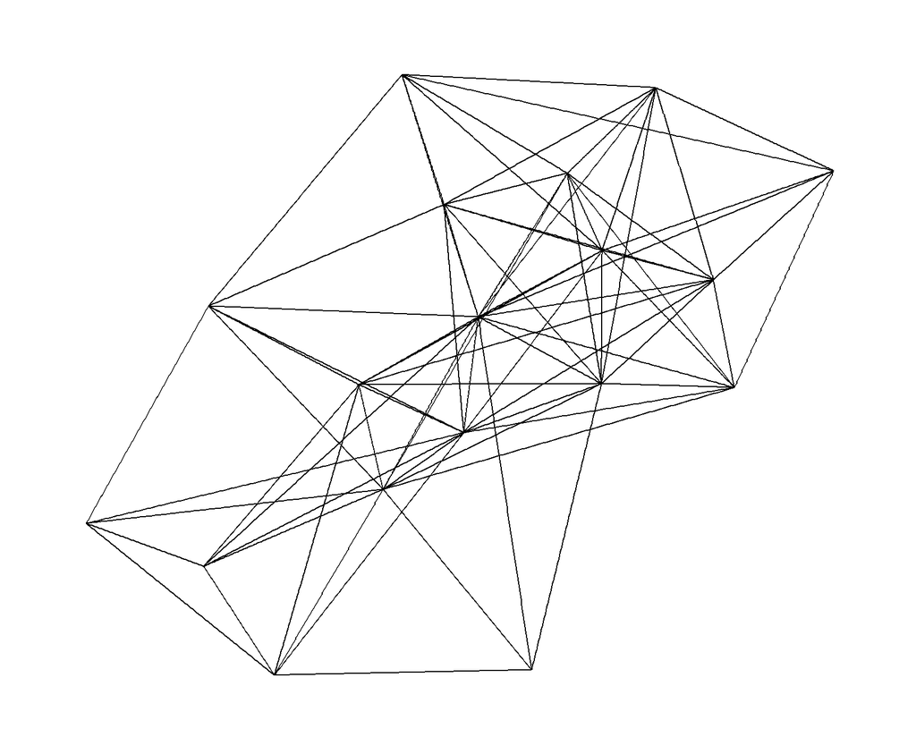

```r
poke_fuerza%>%
  ggraph() +
  geom_edge_link() +
  theme_graph()
```

```r
poke_fuerza%>%
  ggraph() +
  geom_node_point() +
  theme_graph()
```

[output not shown]

[output not shown]

Por supuesto, una visualización que incluya uniones y nodos se vería como la combinación de las dos visualizaciones anteriores.

```
## Using `nicely` as default layout
```

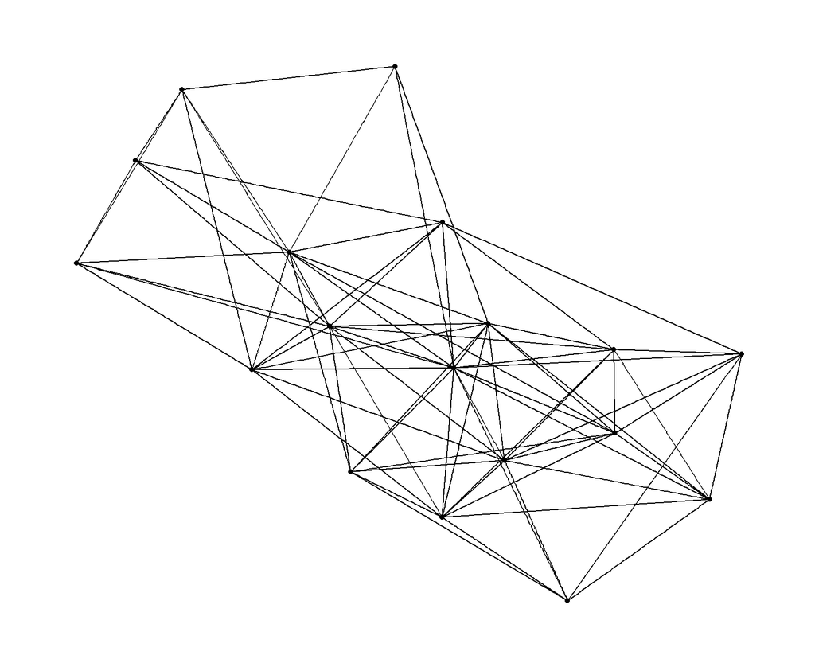

```r
poke_fuerza%>%
  ggraph() +
  geom_edge_link() +
  geom_node_point() +
  theme_graph()
```

Habrás notado que aparece el siguiente mensaje al generar las redes anteriores: `## Using`nicely`as default layout`.

Al crear una red podemos elegir entre diferentes formas para distribuir nuestra red o “*layouts*”. *nicely* es un *layout* que intenta distribuir de manera uniforme los nodos y uniones de nuestras redes, pero tenemos más opciones.

El *layout* *linear* ordena todos los nodos en una línea recta.

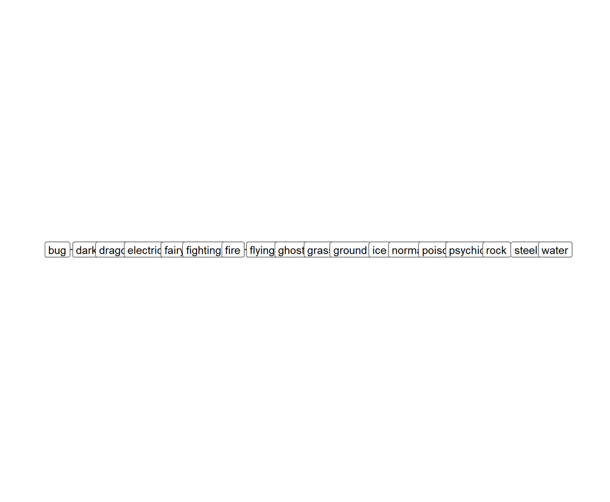

```r
poke_fuerza%>%
  ggraph(layout = "linear") +
  geom_edge_link() +
  geom_node_label(aes(label = name)) +
  theme_graph()
```

El resultado es una gráfica poco informativa, pues no son visibles las uniones entre nodos.

Para solucionar este problema, cambiamos `geom_edge_link()` por `geom_edge_arc()`. De esta manera, reemplazamos uniones con líneas rectas por uniones en forma de arco.

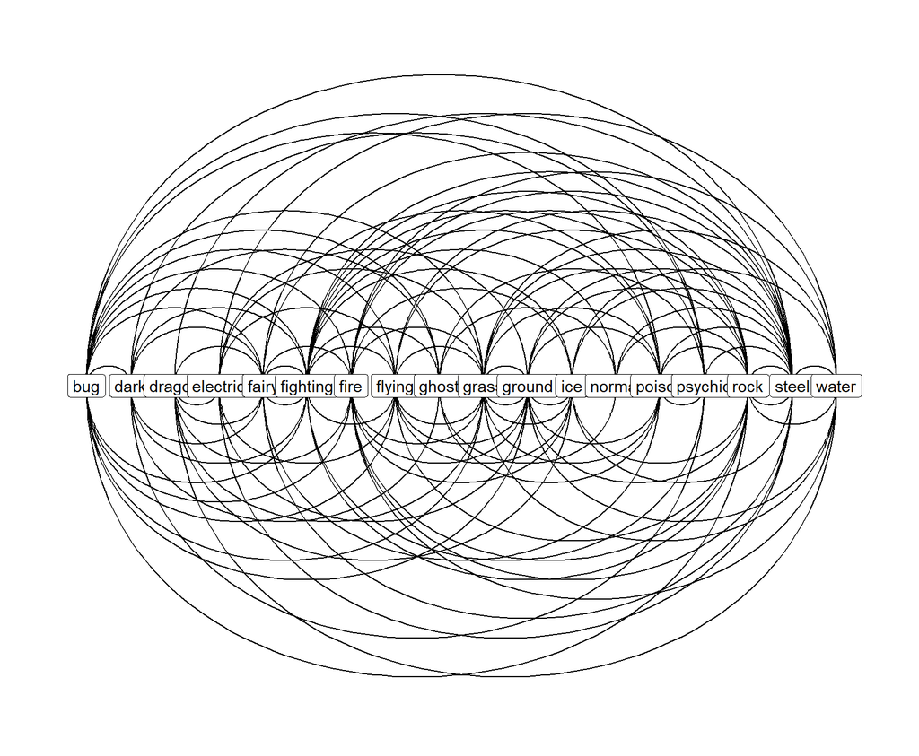

```r
poke_fuerza%>%
  ggraph(layout = "linear") +
  geom_edge_arc() +
  geom_node_label(aes(label = name)) +
  theme_graph()
```

Esta es una visualización que resulta útil cuando tenemos muchas relaciones de recoprocidad, difíciles de colocar de manera uniforme en un plano.

Otro *layout* es *circle*, que coloca a todos los nodos formando un círculo.

[figure not shown]

```r
poke_fuerza %>%
  ggraph(layout = "circle") +
  geom_edge_link() +
  geom_node_label(aes(label = name)) +
  theme_graph()
```

# Layout con arcos

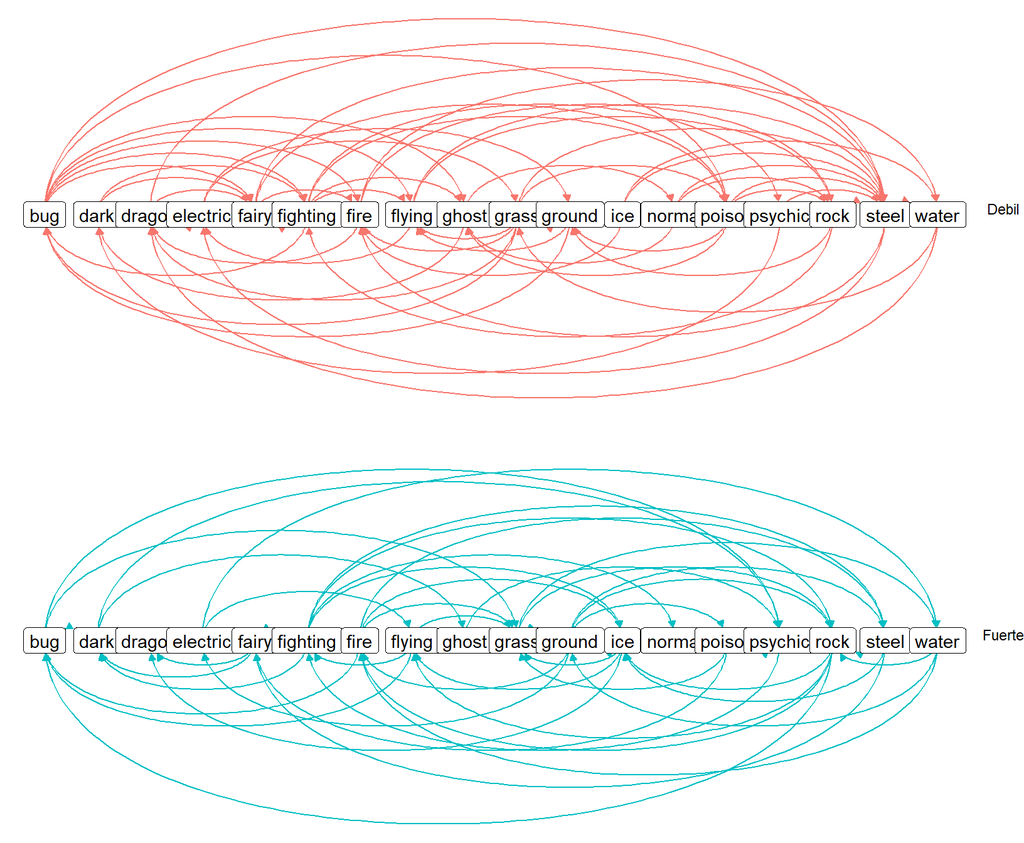

```r
poke_fuerza %>%
  ggraph(layout = "linear") +
  geom_edge_arc(aes(color = Relacion, end_cap = label_rect(node2.name)),
                arrow = arrow(type = "closed", length = unit(1.5, "mm"))) +
  geom_node_point() +
  geom_node_label(aes(label = name)) +
  facet_grid(Relacion~.) +
  theme_void() +
  theme(legend.position = "none")
```

# Layout en circulo

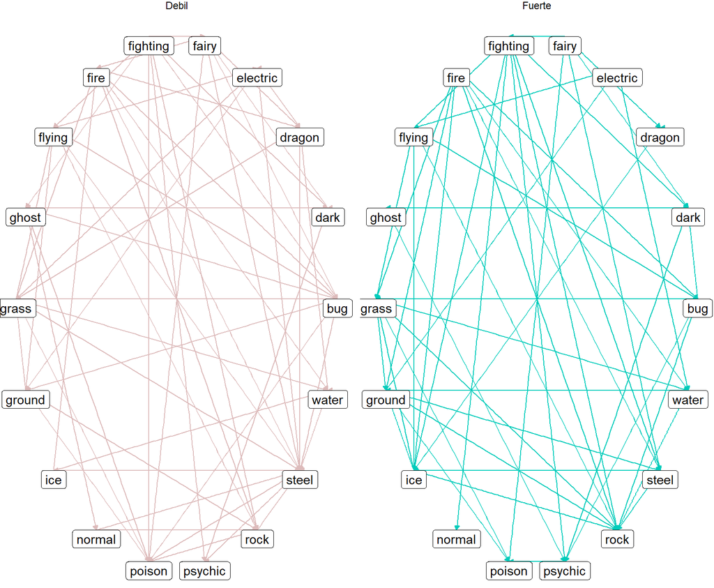

```r
poke_fuerza %>%
  ggraph(layout = "circle") +
  geom_edge_link(aes(color = Relacion),
                 arrow = arrow(type = "closed", length = unit(1.5, "mm"))) +
  geom_node_label(aes(label = name), vjust = 1) +
  facet_wrap("Relacion") +
  theme_void() +
  theme(legend.position = "none") +
  scale_edge_color_manual(values = c("#ddbbbb", "#00ccbb"))
```

# Layout normal

```
## Using `nicely` as default layout
```

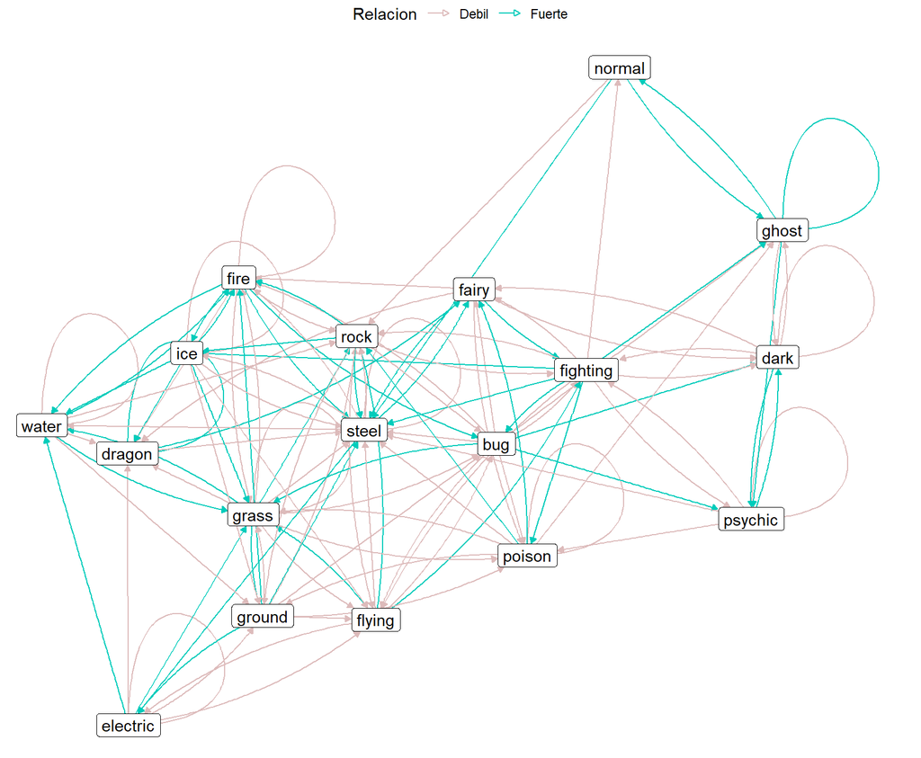

```r
poke_fuerza %>%
  ggraph() +
  geom_edge_loop(aes(color = Relacion)) +
  geom_edge_fan(arrow = arrow(type = "closed", length = unit(1.5, "mm")),
                aes(end_cap = label_rect(node2.name), color = Relacion)) +
  geom_node_label(aes(label = name)) +
  theme_void() +
  theme(legend.position = "top") +
  scale_edge_color_manual(values = c("#ddbbbb", "#00ccbb"))
```

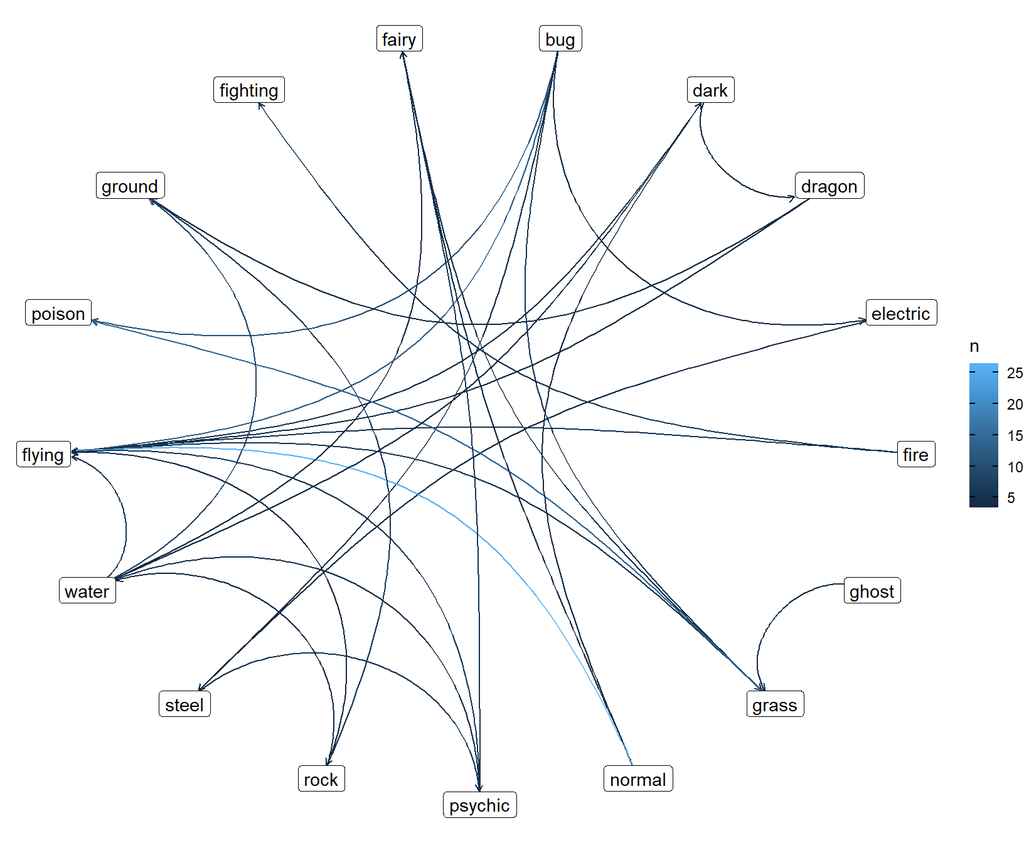

```r
pokemon %>%
  count(type1, type2) %>%
  filter(n > 3) %>%
  na.omit() %>%
  graph_from_data_frame() %>%
  ggraph(layout = "linear", circular = TRUE) +
  geom_edge_arc(aes(color = n, end_cap = label_rect(node2.name)),
                 arrow = arrow(length = unit(1.5, "mm"))) +
  geom_node_label(aes(label = name)) +
  theme_void()
```

```r
pokemon$abilities[pokemon$name == "Starmie"]
```

```
## [1] "['Illuminate', 'Natural Cure', 'Analytic']"
```

```r
pokemon_habilidades <-
  pokemon %>%
  select(name, type1, type2, abilities) %>%
  mutate_at("abilities", function(x) {
    gsub("(\\[|\\'|\\]|,)+", "_", x) %>%
      gsub("^_|_$", "", .) %>%
      gsub("_ _", "_", .) %>%
      trimws()
  }) %>%
  separate(col = "abilities", into = c(letters[1:6]), sep = "_") %>%
  mutate_at(letters[1:6], as.factor) %>%
  gather("Orden_H", "Habilidad", a:f) %>%
  gather("Orden_T", "Tipo", type1, type2) %>%
  select(Tipo, Habilidad, name) %>%
  na.omit()
```

```
## Using `nicely` as default layout
```

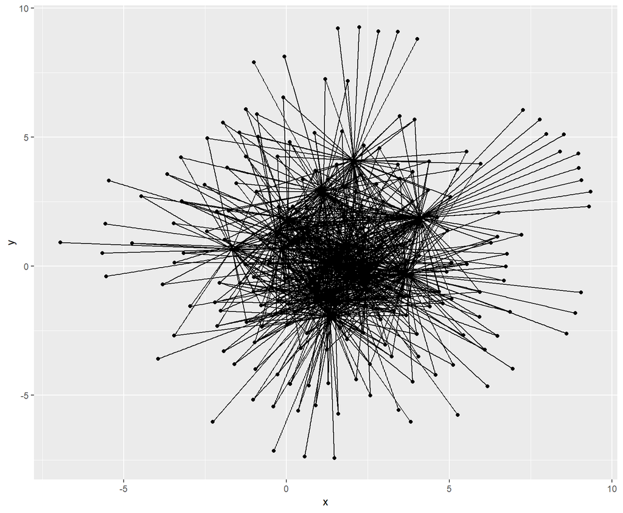

```r
pokemon_habilidades %>%
  count(Tipo, Habilidad) %>%
  graph_from_data_frame() %>%
  ggraph() +
  geom_edge_link() +
  geom_node_point()
```

```
## Using `nicely` as default layout
```

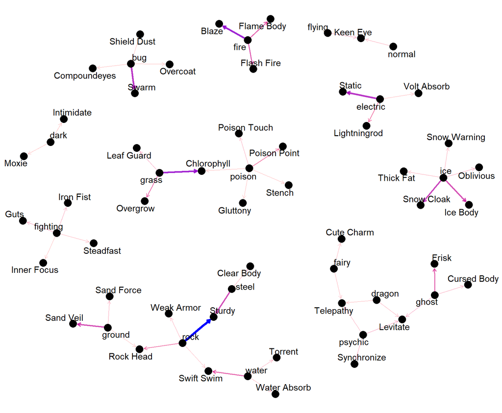

```r
pokemon_habilidades %>%
  count(Tipo, Habilidad) %>%
  group_by(Tipo) %>%
  mutate(prop = n / sum(n)) %>%
  filter(prop >= .05) %>%
  graph_from_data_frame() %>%
  ggraph() +
  geom_edge_link(aes(end_cap = circle(radius = 2, unit = "mm"),
                     color = prop, alpha = prop, edge_width = prop),
                 arrow = arrow(type = "open", length = unit(1.5, "mm")),
                 show.legend = FALSE) +
  scale_edge_color_continuous(low = "red", high = "blue") +
  scale_edge_width(range = c(.01, 1.3)) +
  scale_edge_alpha(range = c(.3, 1)) +
  geom_node_point(size = 4) +
  geom_node_text(aes(label = name), repel = TRUE) +
  theme_void()
```